# Preliminary analysis of automated facial action coding in genuine and performed smiles

## 2.2 Key finding two: Does peak intensity measure the smile, or the length of the clip?

- **Method / Approach / Strategy**

  Each candidate outcome was regressed on standardised clip duration in a mixed model with crossed random intercepts. To test whether any association was a sampling artefact, peak AU12 was recomputed over a fixed 21-frame window — the length of the shortest clip — and the model refitted.
- **Observation**

  Covary clip duration for all peak and timing outcomes, not only cumulative ones. Report a fixed-window peak as a sensitivity check. Prefer `duchenne_prop`, which is immune to the artefact.

**Main result**

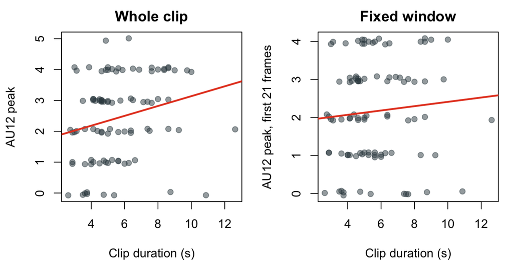

Figure 3: Left: peak AU12 over the whole clip rises with duration. Right: peak over the first 21 frames shows no such rise, indicating the left-hand pattern is an artefact of maximising over more samples.

```r
tp <- sapply(gen$clip_id, function(id) {
  d <- frames[frames$clip_id == id, ]; max(d$AU12[1:21], na.rm = TRUE)
})
par(mfrow = c(1, 2), mar = c(4.2, 4.2, 2.2, 1))
plot(gen$clip_duration_s, jitter(gen$AU12_pk, .4), pch = 19,
     col = adjustcolor(SLATE, .5), xlab = "Clip duration (s)",
     ylab = "AU12 peak", main = "Whole clip")
abline(lm(AU12_pk ~ clip_duration_s, gen), col = USYD, lwd = 2.4)
plot(gen$clip_duration_s, jitter(tp, .4), pch = 19,
     col = adjustcolor(SLATE, .5), xlab = "Clip duration (s)",
     ylab = "AU12 peak, first 21 frames", main = "Fixed window")
abline(lm(tp ~ gen$clip_duration_s), col = USYD, lwd = 2.4)
```

**Supporting detail**

```r
kable(do.call(rbind, lapply(CONFIRM, function(y) {
  d  <- gen[!is.na(gen[[y]]), ]
  m  <- lmer(as.formula(paste(y, "~ scale(clip_duration_s) + (1|smiler_id) + (1|stimulus)")),
             data = d, REML = TRUE)
  m0 <- lmer(as.formula(paste(y, "~ 1 + (1|smiler_id) + (1|stimulus)")),
             data = d, REML = FALSE)
  lr <- anova(m0, update(m, REML = FALSE))
  ci <- confint(m, parm = "beta_", method = "Wald")[2, ]
  data.frame(Outcome = y, n = nrow(d),
             Beta = round(summary(m)$coefficients[2, 1], 3),
             `95% CI` = sprintf("[%.3f, %.3f]", ci[1], ci[2]),
             `chi-sq` = round(lr$Chisq[2], 2), df = lr$Df[2],
             p = format.pval(lr$`Pr(>Chisq)`[2], digits = 2, eps = .001),
             check.names = FALSE)
})), row.names = FALSE)
```

Table 2: Fixed effect of standardised clip duration on each candidate outcome. Tests are likelihood ratio against the reduced model.

| Outcome | n | Beta | 95% CI | chi-sq | df | p |
| --- | --- | --- | --- | --- | --- | --- |
| AU06_pk | 93 | 0.302 | [0.116, 0.488] | 9.40 | 1 | 0.0022 |
| AU12_pk | 93 | 0.263 | [0.085, 0.441] | 8.15 | 1 | 0.0043 |
| duchenne_prop | 84 | 0.027 | [-0.032, 0.086] | 0.82 | 1 | 0.36 |
| Happy_pk | 93 | 0.053 | [0.011, 0.095] | 6.04 | 1 | 0.014 |

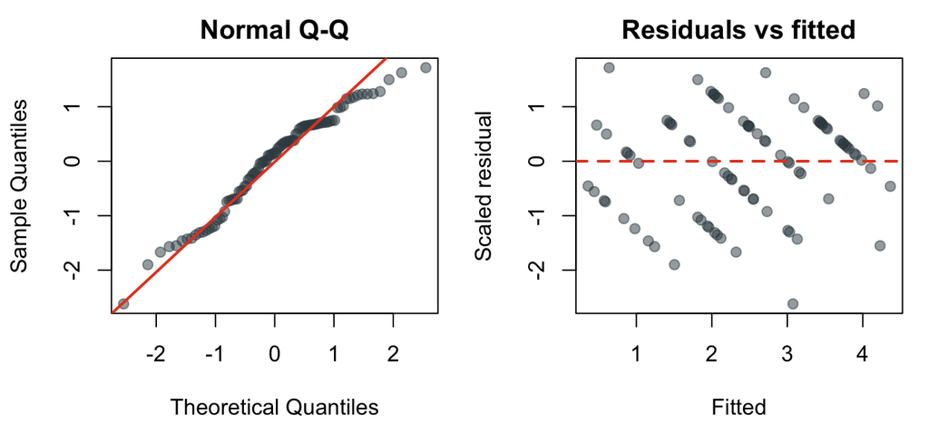

Figure 4: Diagnostics for the AU12 peak model. Residuals are approximately normal with mild discreteness from the ordinal scale, and unrelated to fitted values.

```r
par(mfrow = c(1, 2), mar = c(4.2, 4.2, 2.2, 1))
r <- resid(m12, scaled = TRUE)
qqnorm(r, main = "Normal Q-Q", pch = 19, col = adjustcolor(SLATE, .5))
qqline(r, col = USYD, lwd = 2)
plot(fitted(m12), r, pch = 19, col = adjustcolor(SLATE, .5),
     xlab = "Fitted", ylab = "Scaled residual", main = "Residuals vs fitted")
abline(h = 0, col = USYD, lwd = 2, lty = 2)
```

## 2.3 Key finding three: Can onset, offset and duration be recovered from these clips?

- **Method / Approach / Strategy**

  For every action unit, each clip was flagged as start-censored if the unit was active in the first frame, and end-censored if still active in the final frame, giving the proportion of clips for which onset or offset is unobserved.
- **Observation**

  AU12 is start-censored in 28% of clips and end-censored in 69%; AU06 in 63%. Smile rise rate is computable for only 42 of 93 clips. Sampling is 8 fps rather than the 30 fps expected, quantising timing at 125 ms.
- **Comments**

  Clips were cut tightly around each smile, so recording typically begins after onset and ends before offset. Recorded durations are lower bounds rather than measurements. If censoring rates differ between conditions the comparison is misleading rather than merely imprecise.
- **Recommendation**

  Re-cut from the original recordings with approximately two seconds of padding, which would recover onset, offset and duration. Failing that, use `prop_active` as the duration-like outcome and treat duration with survival methods. Confirm whether the 8 fps downsampling was intended.

**Main result**

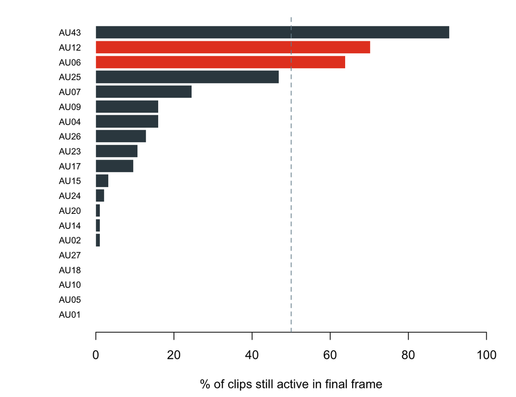

```r
aus   <- grep("^AU[0-9]+_cens1$", names(adat), value = TRUE)
rates <- sort(sapply(aus, function(a) mean(adat[[a]], na.rm = TRUE)))
par(mar = c(4.4, 6.5, 1, 2))
cols <- ifelse(names(rates) %in% c("AU12_cens1", "AU06_cens1"), USYD, SLATE)
barplot(rates * 100, horiz = TRUE, las = 1, xlim = c(0, 100), border = NA,
        names.arg = sub("_cens1", "", names(rates)), cex.names = .72,
        xlab = "% of clips still active in final frame", col = cols)
abline(v = 50, lty = 2, col = MID)
```

**Supporting detail**

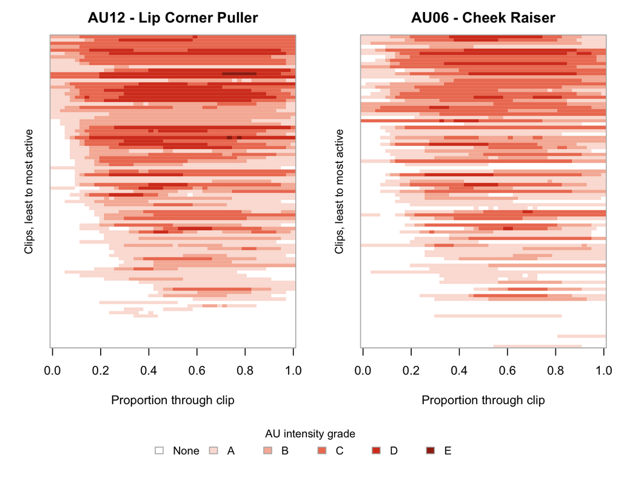

Figure 6: Every genuine clip’s AU12 and AU06 time course, one row per clip, time normalised and shade giving intensity grade. Bands reaching the right-hand edge are right-censored; pale rows at the foot of the AU12 panel are clips with no lip-corner activation at all.

```r
raster_matrix <- function(ch, ids, k = 50) {
  t(sapply(ids, function(id) {
    v <- frames[[ch]][frames$clip_id == id]
    approx(seq(0, 1, length.out = length(v)), v,
           xout = seq(0, 1, length.out = k), method = "constant", rule = 2)$y
  }))
}
ord <- gen$clip_id[order(gen$AU12_prop)]
pal <- colorRampPalette(c("#FFFFFF", "#FBD9CF", "#F4A28A", "#E64626", "#9E2A14"))(6)
layout(matrix(c(1, 2, 3, 3), nrow = 2, byrow = TRUE), heights = c(6, 1))
par(mar = c(4.2, 3.4, 2.4, 1))
for (ch in c("AU12", "AU06")) {
  m <- raster_matrix(ch, ord)
  image(x = seq(0, 1, length.out = ncol(m)), y = seq_len(nrow(m)), z = t(m),
        col = pal, zlim = c(0, 5), axes = FALSE,
        xlab = "Proportion through clip", ylab = "",
        main = paste0(ch, if (ch == "AU12") " - Lip Corner Puller"
                          else " - Cheek Raiser"))
  axis(1); box(col = "grey70")
  mtext("Clips, least to most active", side = 2, line = 1, cex = .75)
}
par(mar = c(0, 0, 0, 0)); plot.new()
legend("center", legend = c("None", "A", "B", "C", "D", "E"), fill = pal,
       border = "grey70", bty = "n", cex = .9, horiz = TRUE,
       title = "AU intensity grade")
layout(1)
```

```r
aud <- clip[clip$channel_type == "action_unit", ]
ct <- do.call(rbind, lapply(split(aud, aud$channel), function(d) {
  data.frame(AU = d$channel[1],
             `Start n` = sum(d$censored_start),
             `Start %` = round(100 * mean(d$censored_start), 1),
             `End n`   = sum(d$censored_end),
             `End %`   = round(100 * mean(d$censored_end), 1),
             check.names = FALSE)
}))
kable(ct[order(-ct$`End %`), ], row.names = FALSE)
```

Table 3: Censoring by action unit across all 95 usable clips.

| AU | Start n | Start % | End n | End % |
| --- | --- | --- | --- | --- |
| AU43 | 62 | 65.3 | 86 | 90.5 |
| AU12 | 27 | 28.4 | 66 | 69.5 |
| AU06 | 20 | 21.1 | 60 | 63.2 |
| AU25 | 26 | 27.4 | 44 | 46.3 |
| AU07 | 11 | 11.6 | 23 | 24.2 |
| AU04 | 11 | 11.6 | 15 | 15.8 |
| AU09 | 11 | 11.6 | 15 | 15.8 |
| AU26 | 6 | 6.3 | 12 | 12.6 |
| AU23 | 11 | 11.6 | 11 | 11.6 |
| AU17 | 8 | 8.4 | 9 | 9.5 |
| AU15 | 3 | 3.2 | 3 | 3.2 |
| AU24 | 5 | 5.3 | 2 | 2.1 |
| AU02 | 6 | 6.3 | 1 | 1.1 |
| AU14 | 1 | 1.1 | 1 | 1.1 |
| AU20 | 1 | 1.1 | 1 | 1.1 |
| AU01 | 5 | 5.3 | 0 | 0.0 |
| AU05 | 1 | 1.1 | 0 | 0.0 |
| AU10 | 2 | 2.1 | 0 | 0.0 |
| AU18 | 0 | 0.0 | 0 | 0.0 |
| AU27 | 0 | 0.0 | 0 | 0.0 |

## 2.4 Key finding four: Are all the clips usable?

- **Method / Approach / Strategy**

  All 108 exports were parsed and audited. Each clip records its stimulus twice — once as the source video name, once in the internal clip code — and the two were cross-checked. Clips were also screened for activation of AU12, the defining smile action.
- **Observation**

  95 files parsed. 13 are state logs containing only dominant-expression transitions, with no action-unit data (all of C15, all of C31, one C24 clip). 1 clip (`E25SA07-03`) is coded SA while its source video is `Happy 7 CN`. 9 genuine-labelled clips show no AU12 activation in any frame.
- **Comments**

  The smile-less clips are not tracking failures: all have zero `FIT_FAILED` cells and other action units activate normally, but they average 2.6 active units against 5.9 elsewhere, and peak happiness 0.08 against 0.75. Mis-segmentation is the likely explanation. Retained, they would depress the genuine mean and inflate within-group variance.
- **Recommendation**

  Re-export the 13 state logs, which would recover two smilers. Clarify `E25SA07-03`. Adopt a rule excluding clips with no AU12 activation, applied blind to condition and reported with a sensitivity analysis both ways.

**Main result**

```r
nc <- null_clips[, c("clip_id", "smiler_id", "stimulus", "clip_duration_s",
                     "AU12_pk", "AU06_pk", "Happy_pk")]
nc$Happy_pk <- round(nc$Happy_pk, 3)
names(nc) <- c("Clip", "Smiler", "Stimulus", "Duration (s)",
               "AU12 peak", "AU06 peak", "Happy peak")
kable(nc, row.names = FALSE)
```

Table 4: Genuine-labelled clips in which AU12 never activates. Peaks are on the 0–5 ordinal scale; Happy is a probability.

| Clip | Smiler | Stimulus | Duration (s) | AU12 peak | AU06 peak | Happy peak |
| --- | --- | --- | --- | --- | --- | --- |
| E17HA02-01 | C17 | Happy 2 CN | 8.750 | 0 | 1 | 0.144 |
| E17HA05-05 | C17 | Happy 5 CN | 3.750 | 0 | 0 | 0.023 |
| E17HA07-02 | C17 | Happy 7 CN | 3.625 | 0 | 0 | 0.171 |
| E18HA06-01 | C18 | Happy 6 CN | 3.500 | 0 | 1 | 0.073 |
| E25HA03-01 | C25 | Happy 3 CN | 5.375 | 0 | 0 | 0.120 |
| E25HA04-01 | C25 | Happy 4 CN | 10.875 | 0 | 0 | 0.023 |
| E25HA04-04 | C25 | Happy 4 CN | 4.750 | 0 | 0 | 0.009 |
| E27HA05-02 | C27 | Happy 5 CN | 2.625 | 0 | 0 | 0.140 |
| E27HA07-01 | C27 | Happy 7 CN | 3.750 | 0 | 0 | 0.051 |

**Supporting detail**

```r
lab <- ifelse(is.na(ok$smile_type) | ok$smile_type == "", "Unresolved", ok$smile_type)
st  <- as.data.frame.matrix(table(ok$culture, lab))
kable(cbind(Culture = rownames(st), st), row.names = FALSE)
```

Table 5: Current design coverage. The genuine-versus-performed contrast is not yet testable.

| Culture | Fake | Genuine | Unresolved |
| --- | --- | --- | --- |
| Chinese | 1 | 93 | 1 |

```r
sm <- as.data.frame(table(gen$smiler_id)); names(sm) <- c("Smiler", "Clips")
sm <- sm[sm$Clips > 0, ]
sti <- as.data.frame(table(gen$stimulus)); names(sti) <- c("Stimulus", "Clips")
n <- max(nrow(sm), nrow(sti))
pad <- function(d, n) { d[] <- lapply(d, as.character)
  if (nrow(d) < n) d[(nrow(d)+1):n, ] <- ""; d }
kable(cbind(pad(sm, n), pad(sti, n)), row.names = FALSE, align = "lrlr")
```

Table 6: Genuine clips per smiler and per stimulus. The unbalance is why repeated-measures ANOVA is unsuitable.

| Smiler | Clips | Stimulus | Clips |
| --- | --- | --- | --- |
| C11 | 6 | Happy 1 CN | 15 |
| C13 | 6 | Happy 2 CN | 16 |
| C14 | 6 | Happy 3 CN | 14 |
| C17 | 6 | Happy 4 CN | 11 |
| C18 | 6 | Happy 5 CN | 14 |
| C19 | 6 | Happy 6 CN | 11 |
| C20 | 6 | Happy 7 CN | 12 |
| C22 | 6 |  |  |
| C23 | 6 |  |  |
| C24 | 5 |  |  |
| C25 | 5 |  |  |
| C26 | 6 |  |  |
| C27 | 6 |  |  |
| C28 | 6 |  |  |
| C30 | 6 |  |  |
| C32 | 5 |  |  |

## 2.5 Key finding five: What will the study be able to detect?

- **Method / Approach / Strategy**

  Power was estimated by simulation using variance components from the pilot data (between-smiler SD 1.04, residual SD 0.885), with 3–6 clips per smiler per condition and the interaction set at half the main effect. 500 replicates per cell at *d* = 0.5.
- **Observation**

  The asymmetry is structural. Smile type operates within smiler and is tested efficiently; the interaction asks whether that within-smiler effect differs between groups, a between-smiler contrast where the design is thinnest. A null interaction would therefore be ambiguous between a genuinely absent effect and one that could not be detected.
- **Recommendation**

  Frame the interaction as exploratory, reporting effect size with confidence intervals rather than relying on significance, unless substantially more smilers per culture are available. Confirming the total number of smilers would settle this.

**Main result**

```r
pt <- pow[pow$effect_d == 0.5, c("smilers_per_culture", "power_main", "power_interaction")]
names(pt) <- c("Smilers per culture", "Power: main effect", "Power: interaction")
kable(pt, row.names = FALSE)
```

Table 7: Simulated power at α = .05 for a moderate effect (d = 0.5), 500 replicates.

| Smilers per culture | Power: main effect | Power: interaction |
| --- | --- | --- |
| 10 | 0.672 | 0.118 |
| 20 | 0.946 | 0.220 |
| 30 | 0.988 | 0.340 |

**Supporting detail**

```r
pf <- pow
names(pf) <- c("Smilers per culture", "Effect d", "Power: main",
               "Power: interaction", "Replicates")
kable(pf, row.names = FALSE)
```

Table 8: Full simulated power grid. Monte Carlo SE is about 2 percentage points at 500 replicates and 4 at 150, so small non-monotonicities are simulation noise.

| Smilers per culture | Effect d | Power: main | Power: interaction | Replicates |
| --- | --- | --- | --- | --- |
| 10 | 0.3 | 0.350 | 0.076 | 500 |
| 20 | 0.3 | 0.530 | 0.132 | 500 |
| 30 | 0.3 | 0.748 | 0.156 | 500 |
| 10 | 0.5 | 0.672 | 0.118 | 500 |
| 20 | 0.5 | 0.946 | 0.220 | 500 |
| 30 | 0.5 | 0.988 | 0.340 | 500 |
| 10 | 0.8 | 0.978 | 0.264 | 500 |
| 20 | 0.8 | 1.000 | 0.442 | 500 |
| 30 | 0.8 | 1.000 | 0.642 | 500 |

```r
cm <- cor(gen[, CONFIRM], use = "pairwise.complete.obs")
kable(round(cm, 3))
```

Table 9: Correlations among candidate outcomes, genuine clips (n = 93). AU12 peak and Happy peak are near-redundant.

|  | AU06_pk | AU12_pk | duchenne_prop | Happy_pk |
| --- | --- | --- | --- | --- |
| AU06_pk | 1.000 | 0.748 | 0.761 | 0.731 |
| AU12_pk | 0.748 | 1.000 | 0.492 | 0.847 |
| duchenne_prop | 0.761 | 0.492 | 1.000 | 0.539 |
| Happy_pk | 0.731 | 0.847 | 0.539 | 1.000 |

`AU12_pk` and `Happy_pk` correlate at 0.85, unsurprising given that FaceReader’s happiness classifier is substantially driven by lip-corner movement. Substituting a temporally informative measure for `Happy_pk` would increase the independent information in the confirmatory set.

## 2.6 Next steps

Ordered by who is blocked on what.

| Step | Action | Owner |
| --- | --- | --- |
| 1 | Confirm whether original recordings can be re-cut with padding | Zoey |
| 2 | Re-export the 13 state-log files as detailed logs | Zoey |
| 3 | Clarify the stimulus for `E25SA07-03` | Zoey |
| 4 | Confirm total smilers per culture, and whether NZ European smilers viewed the same videos | Zoey |
| 5 | Agree the exclusion rule for smile-less clips and the confirmatory outcome set | All |
| 6 | Transfer remaining three data cells via shared OneDrive | Zoey |
| 7 | Re-run pipeline in full mode; cross-check headline results in SPSS | Delphine |
| 8 | Circulate results before interpretation is written | All |

# 3 Appendix

## 3.1 Project overview

The study compares smiles produced under two conditions. Participants watched humorous videos, producing spontaneous smiles, and sad videos, during which they were instructed to smile regardless. Smile episodes were segmented manually and processed through FaceReader. Smilers were drawn from Chinese and New Zealand European backgrounds.

The analytic question is whether the two smile types separate on objective facial measures, and whether that separation differs by the smiler’s cultural background. The second question is the theoretically motivated one: if masking felt emotion is more culturally normative, performed smiles from that group may be physically closer to genuine ones, which would help explain existing emotion-recognition findings rather than merely restating them.

A third question requires no new data. Human judgement data already exists for these clips, so FaceReader measures can be related to per-clip human accuracy — asking whether observers use the signal that is objectively present.

## 3.2 Data overview

108 FaceReader exports were received, of which 95 are usable. Each is one manually segmented smile episode. Every frame carries eight emotion probabilities (0–1) and intensity grades for 20 action units (NotActive, A–E, recoded 0–5). Sampling is 8 fps and the median clip runs 5.0 s.

Current coverage is 93 genuine clips and one performed clip from 16 smilers, all Chinese. The remaining three cells — Chinese performed, NZ European genuine, NZ European performed — are outstanding, so the central contrast is not yet testable. The pipeline runs in pilot mode, producing derived variables, descriptives and diagnostics while reporting inferential models as blocked, and switches to full mode automatically when those data arrive.

Clips are identified by an internal code (`E11HA01-01`) giving culture, smiler, stimulus type and take. Export filenames are unreliable: the `Participant_###` fields are upload identifiers rather than people, and the sequential clip number does not always match the stimulus.

## 3.3 Analytical rationale

The unit of analysis is one smile episode. Smile type is within-smiler, culture between-smiler, and stimulus videos recur across smilers. The proposed model is

$$y_{ijk} = \beta_0 + \beta_1 \text{type}_{ijk} + \beta_2 \text{culture}_j
+ \beta_3 (\text{type} \times \text{culture})_{ijk}
+ u_j + v_k + \varepsilon_{ijk}$$

with $u_j$ for smiler $j$, $v_k$ for stimulus $k$. Estimation by REML; inference by likelihood ratio test against the reduced model fitted by ML. Clip duration is covaried for peak, timing and cumulative outcomes.

Mixed models are indicated for three reasons. The design is unbalanced, so repeated-measures ANOVA would require averaging within person, weighting a smiler contributing one clip equally with one contributing eight. Smilers with no clips in a condition are retained rather than deleted listwise. And stimulus variance, if unmodelled, inflates Type I error.

Four confirmatory outcomes are proposed — `AU06_pk`, `AU12_pk`, `duchenne_prop` and `Happy_pk` — reported without multiplicity correction as a small pre-specified set, with all remaining action units screened as exploratory under Benjamini–Hochberg at *q* = .05. Fixing this split before the data are seen matters: roughly 300 tests are available across 20 action units, 8 emotion channels and 10 measures each.

Action-unit grades are treated as continuous. This is an approximation — the scale is ordinal and grade E is almost unused, leaving five working levels — so the confirmatory outcomes should be re-run as ordinal mixed models (cumulative link) as a sensitivity check.

## 3.4 Relation to trajectory-based approaches

An alternative framing represents each smile as an oriented trajectory in AU-intensity space, analysed under reparameterisation so that ordering and coordination rather than execution speed carry the signal. The motivating diagnosis matches the censoring and duration findings above: clip boundaries do not correspond to smile boundaries, and speed reflects the eliciting event and individual style alongside genuineness.

Three properties of the present data bear on feasibility. At 8 fps the median clip holds 40 frames, where elastic functional methods and higher-order signature representations generally assume denser sampling. FaceReader detailed logs are ordinal with five working levels, so trajectories are step functions rather than differentiable paths; OpenFace returns continuous intensities and would suit these methods considerably better, so confirming which software supplies the final measurements would be useful. And with approximately 23 effective independent observations, high-dimensional descriptors would carry substantial uncertainty.

A tractable intermediate exists. Restricting attention to the action units the hypothesis names — AU06, AU12, optionally AU25 — makes a low-order path signature feasible: for $d$ channels the level-2 signature has $d + d^2$ terms, so 12 features for $d = 3$. The level-2 antisymmetric terms encode lead–lag ordering directly, which is the Duchenne question in temporal form: does cheek raise precede, accompany or follow lip-corner movement, and does that ordering differ by condition? Such features are scale-free and reparameterisation-invariant, inheriting the robustness that motivates the trajectory framing, while entering the same mixed model as the outcomes above.

## 3.5 Glossary

```r
glossary <- data.frame(rbind(

  c("Action Unit (AU)",
  "A single facial muscle movement in the Facial Action Coding System. FaceReader scores 20 of them per frame. AU06 (cheek raiser) and AU12 (lip corner puller) are central here."),

  c("Duchenne smile",
  "A smile involving both lip-corner movement (AU12) and cheek raise (AU06). The cheek raise is held to be difficult to produce voluntarily, making it a candidate marker of genuineness."),

  c("duchenne_prop",
  "Derived measure: of the frames in which AU12 is active, the proportion in which AU06 is also active. Captures co-occurrence rather than independent peaks, and is unaffected by clip length."),

  c("Intraclass correlation (ICC)",
  "The proportion of total variance attributable to a grouping factor. An ICC of 0.64 for smiler means 64% of variation lies between people rather than between their individual smiles."),

  c("Design effect",
  "The factor by which clustering inflates variance relative to independent sampling. A design effect of 4.1 means 93 clustered clips carry the information of about 23 independent observations."),

  c("Linear mixed model",
  "A regression model containing both fixed effects (smile type, culture) and random effects (smiler, stimulus), allowing correlated observations from the same person to be modelled rather than averaged away."),

  c("Random intercept",
  "A per-group deviation from the overall average, here allowing each smiler their own baseline expressiveness."),

  c("REML",
  "Restricted maximum likelihood, the default estimator for variance components in mixed models. Models differing in fixed effects must be compared under ML, not REML."),

  c("Right-censoring",
  "An event whose endpoint is not observed. Here, an action unit still active in the final frame has an unknown offset, so its recorded duration is a lower bound."),

  c("Benjamini-Hochberg FDR",
  "A multiplicity correction controlling the expected proportion of false positives among significant results. Less conservative than Bonferroni and appropriate for exploratory screens."),

  c("Confirmatory vs exploratory",
  "Confirmatory outcomes are specified before the data are seen and reported without correction; exploratory analyses are corrected and reported as hypothesis-generating."),

  c("Hedges' g",
  "A standardised mean difference with a small-sample correction. Used here to express effect magnitude alongside p-values."),

  c("State log vs detailed log",
  "Two FaceReader export formats. Detailed logs give per-frame emotion and action-unit values; state logs give only dominant-expression transitions and cannot be used for this analysis."),

  c("FIT_FAILED",
  "A FaceReader cell indicating the model could not fit that frame. Recoded to missing, never to zero."),

  c("Pilot mode / full mode",
  "The analysis script detects whether design coverage supports the planned models. In pilot mode it reports inferential models as blocked; it switches to full mode automatically when the remaining data arrive.")
), stringsAsFactors = FALSE)
names(glossary) <- c("Term", "Definition")

if (requireNamespace("DT", quietly = TRUE)) {
  DT::datatable(glossary, rownames = FALSE,
                options = list(dom = "Bfrtip", pageLength = 10, scrollX = TRUE))
} else {
  knitr::kable(glossary)
}
```

| Term | Definition |
| --- | --- |
| Action Unit (AU) | A single facial muscle movement in the Facial Action Coding System. FaceReader scores 20 of them per frame. AU06 (cheek raiser) and AU12 (lip corner puller) are central here. |
| Duchenne smile | A smile involving both lip-corner movement (AU12) and cheek raise (AU06). The cheek raise is held to be difficult to produce voluntarily, making it a candidate marker of genuineness. |
| duchenne_prop | Derived measure: of the frames in which AU12 is active, the proportion in which AU06 is also active. Captures co-occurrence rather than independent peaks, and is unaffected by clip length. |
| Intraclass correlation (ICC) | The proportion of total variance attributable to a grouping factor. An ICC of 0.64 for smiler means 64% of variation lies between people rather than between their individual smiles. |
| Design effect | The factor by which clustering inflates variance relative to independent sampling. A design effect of 4.1 means 93 clustered clips carry the information of about 23 independent observations. |
| Linear mixed model | A regression model containing both fixed effects (smile type, culture) and random effects (smiler, stimulus), allowing correlated observations from the same person to be modelled rather than averaged … |
| Random intercept | A per-group deviation from the overall average, here allowing each smiler their own baseline expressiveness. |
| REML | Restricted maximum likelihood, the default estimator for variance components in mixed models. Models differing in fixed effects must be compared under ML, not REML. |
| Right-censoring | An event whose endpoint is not observed. Here, an action unit still active in the final frame has an unknown offset, so its recorded duration is a lower bound. |
| Benjamini-Hochberg FDR | A multiplicity correction controlling the expected proportion of false positives among significant results. Less conservative than Bonferroni and appropriate for exploratory screens. |
| Confirmatory vs exploratory | Confirmatory outcomes are specified before the data are seen and reported without correction; exploratory analyses are corrected and reported as hypothesis-generating. |
| Hedges’ g | A standardised mean difference with a small-sample correction. Used here to express effect magnitude alongside p-values. |
| State log vs detailed log | Two FaceReader export formats. Detailed logs give per-frame emotion and action-unit values; state logs give only dominant-expression transitions and cannot be used for this analysis. |
| FIT_FAILED | A FaceReader cell indicating the model could not fit that frame. Recoded to missing, never to zero. |
| Pilot mode / full mode | The analysis script detects whether design coverage supports the planned models. In pilot mode it reports inferential models as blocked; it switches to full mode automatically when the remaining data … |

[session information not shown]